# As-a-Statistician-Survival Analysis

Zehui Bai

2022-12-19 16:21:38

[interactive chart not shown]

## Preliminary

Survival analysis mainly focuses on processing a special kind of time data, and the time data may be partially censored. The shortcomings of the ordinary least squares regression method are that the event occurrence time is usually not normally distributed, and the model cannot handle Censor. The non-parametric method can simply and quickly check the survival experience, while the Cox proportional hazard regression model is still the main Analytical method.

### Probability density function

The function that describes likelihood of observing Time at time t relative to all other survival times is known as the probability density function the probability of observing a survival time within the interval $[a, b]$ is
$$\operatorname{Pr}(a \leq \text { Time } \leq b)=\int_{a}^{b} f(t) d t=\int_{a}^{b} \lambda e^{-\lambda t} d t$$
### Cumulative distribution function

Describes the probability of observing Time less than or equal to some timet $t$ $\operatorname{Pr}($ Time $\leq t)$
$$\begin{array}{c}
F(t)=\int_{0}^{t} f(t) d t \\
f(t)=\frac{d F(t)}{d t}
\end{array}$$
In SAS, we can graph an estimate of the cdf using proc univariate.

```
proc univariate data = whas500(where=(fstat=1));
    var lenfol;
    cdfplot lenfol;
run;
```

### Survival function

$$S(t)=P(T>t)=1-F(t)$$
The survival function gives the probability that a person survives longer than some specified time $t$ : that is, $S(t)$ gives the probability that the random variable $T$ exceeds the specified time $t .$ And here, some important characteristics:

- It is nonincreasing; that is, it heads downward as $t$ increases.
- At time $t=0, S(t)=S(0)=1$; that is, at the start of the study, since no one has gotten the event yet, the probability of surviving past time zero is one.
- At time $t=\inf , S(t)=S(\mathrm{inf})=0 ;$ that is, theoretically, if the study period increased without limit. eventually nobody would survive, so the survival curve must eventually fall to zero.

Here we can use proc lifetest to graph $S_(t)$.

```
proc lifetest data=whas500(where=(fstat=1)) plots=survival(atrisk);
time lenfol*fstat(0);
run;
```

### Hazard function

The hazard function $h(t)$, is given by the formula:
$$h(t)=\lim _{\Delta_{t} \rightarrow 0} \frac{P(t \leq T<t+\Delta t \mid T \geq t)}{\Delta t}$$
We could say that the hazard function is the probability that if you survive to time $t$, you will experience the event in the next instant, or in other words, the hazard function gives the instantaneous potential per unit time for the event to occur, given that the individual has survived up to time $t$. Because of the given sign here, the hazard function is sometimes called a conditional failure rate.

We can estimate the hazard function is SAS as well using proc lifetest

```
proc lifetest data=whas500(where=(fstat=1)) plots=hazard(bw=200);
    time lenfol*fstat(0);
run;
```

### Cumulative hazard function

Calculated by integrating the hazard function over an interval of time:
$$H(t) = \int_0^th(u)du$$

The cumulative hazard function H(t) and the survival function S(t) have a simple monotonic relationship. Therefore, when the survival function reaches the maximum at the beginning of the analysis time, the cumulative hazard function is the smallest. As time goes by, the survival function advances toward its minimum, and the cumulative hazard function advances toward its maximum. You can use proc lifetest to estimate the cumulative hazard function, and then send the results to proc sgplot for plotting.

```
ods output ProductLimitEstimates = ple;
proc lifetest data=whas500(where=(fstat=1))  nelson outs=outwhas500;
    time lenfol*fstat(0);
run;
proc sgplot data = ple;
    series x = lenfol y = CumHaz;
run;
```

### Mean Residual Life

$$r(t)=E(T-t \mid T \geq t)=\frac{\int_{t}^{\infty} S(u) d u}{S(t)},$$

Intuitively, this is as simple as when I know that I have lived to the time point t and how many years I have to live.

### Relation between functions

The survival function can be ascertained from the probability density function by integrating over the probability density function from time $t$ to infinity, or by calculating the difference between one and the cumulative distribution function $F(t)$. The hazard can then be found by dividing the negative derivative of the survival function by the survival function. Note that the functions $f(t), F(t), h(t)$, and $H(t)$ are all related.

**Assume that $T$ is non-negative and continuos:**

- Probability density function:
  $$f(t)=F^{\prime}(t)=\frac{d F(t)}{d t}$$
- Cumulative distribution function:
  $$F(t)=P(T \leq t)=\int_{0}^{t} f(u) d u$$
- Survival function
  $$\begin{array}{l}
  S(t)=1-F(t)\\
  S(t)=P(T>t)=\int_{t}^{+\infty} f(u) d u \\
  S(t)=\exp \left(-\int_{0}^{t} h(u) d u\right) \\
  S(t)=\exp (-H(t))
  \end{array}$$
- Hazard function
  $$h(t) = \frac{ f(t)}{S(t)}= \frac{ -d[S(t)]/dt}{S(t)}$$
- Cumulative hazard function o Cumulative hazard function
  $$H(t)=\int_{0}^{t} h(u) d u$$

**Assume that $T$ is non-negative and discrete,**

- Probability mass function:
  $$\begin{aligned}
  p\left(t_{i}\right) &=P\left(T=t_{i}\right) \\
  p\left(t_{i}\right) &=S\left(t_{i-1}\right)-S\left(t_{i}\right) \\
  p\left(t_{i}\right) &=F\left(t_{i}\right)-F\left(t_{i-1}\right)
  \end{aligned}$$
- Cumulative distribution function:
  $$F(t)=P(T \leq t)=\sum_{t_{i} \leq t} p\left(t_{i}\right)$$
- Survival function
  $$S(t)=\prod_{t_{i} \leq t}\left(1-h\left(t_{i}\right)\right)$$
- Hazard function
  $$\begin{aligned}
  h(t) &=\frac{p\left(t_{i}\right)}{S\left(t_{i-1}\right)}=\frac{-d[S(t)] / d t}{S(t)} \\
  h(t) &=1-\frac{S\left(t_{i}\right)}{S\left(t_{i-1}\right)}
  \end{aligned}$$
- Cumulative hazard function
  $$H(t)=\sum_{t_{i} \leq t} h\left(t_{i}\right)$$

## Kaplan-Meier estimator

### KM Introduction

$$\hat S(t)=\prod_{t_i\leq t}\frac{n_i – d_i}{n_i},$$

- $n_{i}$ is the number of subjects at risk
- $d_{i}$ is the number of subjects who fail, both at time $t_{i}$, the number who failed out of $n_{i}$

### Nelson-Aalen estimator of the cumulative hazard function

Since it and the survival function $S(t)=e^{-H(t)}$ Nelson-Aalen estimator is a non-parametric estimator of the cumulative hazard function

$$\hat{H}(t)=\sum_{t_{i} l e q t} \frac{d_{i}}{n_{i}}$$

- The Nelson-Aalen estimator is requested in SAS through the nelson option on the proc lifetest statement. SAS will output both Kaplan Meier estimates of the survival function and Nelson-Aalen estimates of the cumulative hazard function in one table.
- Quartile Estimates: Calculating median, mean, and other survival times

```
proc lifetest data=whas500 atrisk nelson;
    time lenfol*fstat(0);
run;
```

### Survival curve in SAS

```
proc lifetest data=whas500 atrisk plots=survival(cb) outs=outwhas500;
  time lenfol*fstat(0);
run;
```

**Graphing the Kaplan-Meier estimate**

- By default, proc lifetest graphs the Kaplan Meier estimate, even without the plot= option on the proc lifetest statement, so we could have used the same code from above that produced the table of Kaplan-Meier estimates to generate the graph.
- However, we would like to add confidence bands and the number at risk to the graph, so we add plots=survival(atrisk cb)

> 生存曲线周围的蓝色阴影区域代表95%置信带，此处为Hall-Wellner置信带。为整 个生存函数计算该置信带，在任何给定的时间间隔内，其宽度必须大于点状置信区 间 (单个间隔附近的置信度间隔)， 以确保所有点状置信区间的95%都包含在该带 中。survivor 函数的许多转换可用于通过conftype选项计算置信区间的替代方法

**Life Table method**

生命表方法如果观察的次数很多，并且如果精确地测量了事件时间，那么将有很多唯一的事件时间。然后，KM方法会生成较长的表，这些表可能难以呈现和解释。

```
ODS GRAPHICS ON;
PROC LIFETEST DATA=recid METHOD=LIFE PLOTS=(S,H);
 TIME week*arrest(0);
RUN;
ODS GRAPHICS OFF;

    Interval    Number   Number    Sample   Probability   Standard
 [Lower, Upper) Failed   Censored  Size     of Failure    Error
  0      10     14       0         432.0    0.0324        0.00852
 10      20     21       0         418.0    0.0502        0.0107
 20      30     23       0         397.0    0.0579        0.0117
 30      40     23       0         374.0    0.0615        0.0124
 40      50     26       0         351.0    0.0741        0.0140
 50      60      7       318       166.0    0.0422        0.0156
```

### KM Survival Plots in SAS

- 在任何被检查的观察结果中，图形都包含加号 (看起来像刻度线)。 当数据集很大且包含大量经过审 查的观察结果时, 这些标记可能会使人分心。可以使用NOCENSOR选项抑制它们.
- 另一个有用的选项是ATRISK，可以将仍然处于危险中 (尚未死亡或受到审查) 的人数添加到图表中。
- 要获得具有幸存者功能95%置信度限制的图形, 请使用CL选项。置信度极限是逐点极限 pointwise limits, 这意味着对于每个指定的生存时间，我们有95%的置信度到那个时间生存的概率在那些极限之 内。置信度限制仅扩展到最大事件时间.
- 假设我们需要置信带 confidence bands that can be interpreted by saying that we are $95 \%$ confident that the entire survivor function falls within the upper curve and the lower curve. More complex methods are needed to produce such bands, and PROC LIFETEST offers two: the HallWellner method and the equal precision (EP) method. 有95%的信心说整个幸存者功能都落在上曲线和下曲线之间。 产生这样的频带需要更复杂的方法, 而 PROC LIFETEST提供两种方法：HallWellner方法和等精度 (EP) 方法。
  - EP方法 倾向于产生在尾部更稳定的置信带。要实现此方法, 该选项将变为PLOTS $=\mathrm{S}(\mathrm{CB}=$ EP) 。 要同时获得逐点频带和EP频带, 请使用选项PLOTS $=\mathrm{S}(\mathrm{CL} \mathrm{CB}=\mathrm{EP})$ 置信带始终比点状 置信极限宽。
  - Other transformations are available, the most attractive being the logit $\log [\hat{S}(t) /(1-\hat{S}(t))]$ To switch to this transform, include the CONFTYPE=LOGIT option in the PROC statement.

```
proc lifetest data=whas500 atrisk  PLOTS=S(NOCENSOR ATRISK CL) OUTSURV=outwhas500;
  time lenfol*fstat(0);
run;
```

**Test in plot**

```
ODS GRAPHICS ON;
PROC LIFETEST DATA=myel PLOTS=S(TEST);
 TIME dur*status(0);
 STRATA treat;
RUN;
ODS GRAPHICS OFF;
```

**log-log survival plots**

LS produces a plot of $-\log \hat{S}(t)$ versus $t$.
$$-\log S(t)=\int_{0}^{t} h(u) d u$$

```
PROC LIFETEST DATA=COMBINE PLOTS=LLS;
 TIME years*event(0);
 STRATA type;
RUN;
```

**Hazard plots**

Examine smoothed hazard plots using the kernel smoothing option

```
ODS GRAPHICS ON;
PROC LIFETEST DATA=combine PLOTS=H(BW=10);
 TIME years*event(0);
 STRATA type;
RUN;
ODS GRAPHICS OFF;

## confidence limits around the hazard function;
PROC LIFETEST DATA=recid PLOTS=H(CL);
```

### Convert Personal-level to Personal-period in R

In studies of survival or modeling discrete-time events, one compact way to store data is in what may be called, “person-level” or generally “observation-level”. For example, you could have three variables, one indicating the observation, one indicating the time period the event occurred or the last follow-up period and one indicating whether the observation was censored.

The PLPP function takes five arguments. The first, data is the data set to be converted. The second, id is the name of the variable containing the identifier for each observation. The third, period is the name of the variable that indicates how many periods the person or observation was in. The fourth, event is the name of the variable that indicates whether the event occurred or not or whether the observation was censored (depending on which direction you are converting). The fifth, direction indicates whether the function should go from person-level to person-period or from person-period to person-level. There are two options, “period” to go to person-period or “level” to go to person-level. Now let’s try it out. For the examples that follow to work, you need to source the function into R.

```r
## Person-Level Person-Period Converter Function
PLPP <- function(data, id, period, event, direction = c("period", "level")){
  ## Data Checking and Verification Steps
  stopifnot(is.matrix(data) || is.data.frame(data))
  stopifnot(c(id, period, event) %in% c(colnames(data), 1:ncol(data)))

  if (any(is.na(data[, c(id, period, event)]))) {
    stop("PLPP cannot currently handle missing data in the id, period, or event variables")
  }
   ## Do the conversion
  switch(match.arg(direction),
    period = {
      index <- rep(1:nrow(data), data[, period])
      idmax <- cumsum(data[, period])
      reve <- !data[, event]
      dat <- data[index, ]
      dat[, period] <- ave(dat[, period], dat[, id], FUN = seq_along)
      dat[, event] <- 0
      dat[idmax, event] <- reve},
    level = {
      tmp <- cbind(data[, c(period, id)], i = 1:nrow(data))
      index <- as.vector(by(tmp, tmp[, id],
        FUN = function(x) x[which.max(x[, period]), "i"]))
      dat <- data[index, ]
      dat[, event] <- as.integer(!dat[, event])
  })

  rownames(dat) <- NULL
  return(dat)
}

## Read in the person-level dataset
teachers <- read.csv("https://stats.idre.ucla.edu/stat/examples/alda/teachers.csv")
## Look at a subset of the cases
subset(teachers, id %in% c(20, 126, 129))
```

|  | id | t | censor |
| --- | --- | --- | --- |
| 19 | 20 | 3 | 0 |
| 125 | 126 | 12 | 0 |
| 128 | 129 | 12 | 1 |

```r
## Uses PLPP to convert to person-period and store in object, 'tpp'
tpp <- PLPP(data = teachers, id = "id", period = "t", event = "censor", direction = "period")
## Look at a subset of the cases
subset(tpp, id %in% c(20, 126, 129))
```

|  | id | t | censor |
| --- | --- | --- | --- |
| 95 | 20 | 1 | 0 |
| 96 | 20 | 2 | 0 |
| 97 | 20 | 3 | 1 |
| 740 | 126 | 1 | 0 |
| 741 | 126 | 2 | 0 |
| 742 | 126 | 3 | 0 |
| 743 | 126 | 4 | 0 |
| 744 | 126 | 5 | 0 |
| 745 | 126 | 6 | 0 |
| 746 | 126 | 7 | 0 |

[output cut: 17 more lines]

```r
### Convert person-period to person-level
## Read in person-period dataset
teachers.pp <- read.csv("https://stats.idre.ucla.edu/stat/examples/alda/teachers_pp.csv")
## Look at a subset of the cases
subset(teachers.pp, id %in% c(20, 126, 129))
```

|  | id | period | event |
| --- | --- | --- | --- |
| 95 | 20 | 1 | 0 |
| 96 | 20 | 2 | 0 |
| 97 | 20 | 3 | 1 |
| 740 | 126 | 1 | 0 |
| 741 | 126 | 2 | 0 |
| 742 | 126 | 3 | 0 |
| 743 | 126 | 4 | 0 |
| 744 | 126 | 5 | 0 |
| 745 | 126 | 6 | 0 |
| 746 | 126 | 7 | 0 |

[output cut: 17 more lines]

### Package survfit in R

```r
## Compute survival curves
library("survival")
library("survminer")

data("lung")
fit <- survfit(Surv(time, status) ~ 1, data = lung)
## Stratification
fit <- survfit(Surv(time, status) ~ sex, data = lung)
summary(fit)
```

```
## Call: survfit(formula = Surv(time, status) ~ sex, data = lung)
##
##                 sex=1
##  time n.risk n.event survival std.err lower 95% CI upper 95% CI
##    11    138       3   0.9783  0.0124       0.9542        1.000
##    12    135       1   0.9710  0.0143       0.9434        0.999
##    13    134       2   0.9565  0.0174       0.9231        0.991
##    15    132       1   0.9493  0.0187       0.9134        0.987
##    26    131       1   0.9420  0.0199       0.9038        0.982
##    30    130       1   0.9348  0.0210       0.8945        0.977
##    31    129       1   0.9275  0.0221       0.8853        0.972
##    53    128       2   0.9130  0.0240       0.8672        0.961
##    54    126       1   0.9058  0.0249       0.8583        0.956
##    59    125       1   0.8986  0.0257       0.8496        0.950
##    60    124       1   0.8913  0.0265       0.8409        0.945
```

[output cut: 142 more lines]

```r
##  Access to the sort summary table
summary(fit)$table
```

```
##       records n.max n.start events   *rmean *se(rmean) median 0.95LCL 0.95UCL
## sex=1     138   138     138    112 326.0841   22.91156    270     212     310
## sex=2      90    90      90     53 460.6473   34.68985    426     348     550
```

```r
##  function survfit() returns a list of variables,components can be accessed as follow:
d <- data.frame(time = fit$time,
                  n.risk = fit$n.risk,
                  n.event = fit$n.event,
                  n.censor = fit$n.censor,
                  surv = fit$surv,
                  upper = fit$upper,
                  lower = fit$lower
                  )
head(d)
```

|  | time | n.risk | n.event | n.censor | surv | upper | lower |
| --- | --- | --- | --- | --- | --- | --- | --- |
| 1 | 11 | 138 | 3 | 0 | 0.9782609 | 1.0000000 | 0.9542301 |
| 2 | 12 | 135 | 1 | 0 | 0.9710145 | 0.9994124 | 0.9434235 |
| 3 | 13 | 134 | 2 | 0 | 0.9565217 | 0.9911586 | 0.9230952 |
| 4 | 15 | 132 | 1 | 0 | 0.9492754 | 0.9866017 | 0.9133612 |
| 5 | 26 | 131 | 1 | 0 | 0.9420290 | 0.9818365 | 0.9038355 |
| 6 | 30 | 130 | 1 | 0 | 0.9347826 | 0.9768989 | 0.8944820 |

```r
## Kaplan-Meier life table: summary of survival curves summary(fit)
res.sum <- surv_summary(fit)
head(res.sum)
```

|  | time | n.risk | n.event | n.censor | surv | std.err | upper | lower | strata | sex |
| --- | --- | --- | --- | --- | --- | --- | --- | --- | --- | --- |
| 1 | 11 | 138 | 3 | 0 | 0.9782609 | 0.01268978 | 1.0000000 | 0.9542301 | sex=1 | 1 |
| 2 | 12 | 135 | 1 | 0 | 0.9710145 | 0.01470747 | 0.9994124 | 0.9434235 | sex=1 | 1 |
| 3 | 13 | 134 | 2 | 0 | 0.9565217 | 0.01814885 | 0.9911586 | 0.9230952 | sex=1 | 1 |
| 4 | 15 | 132 | 1 | 0 | 0.9492754 | 0.01967768 | 0.9866017 | 0.9133612 | sex=1 | 1 |
| 5 | 26 | 131 | 1 | 0 | 0.9420290 | 0.02111708 | 0.9818365 | 0.9038355 | sex=1 | 1 |
| 6 | 30 | 130 | 1 | 0 | 0.9347826 | 0.02248469 | 0.9768989 | 0.8944820 | sex=1 | 1 |

```r
## surv_summary对象还有一个名为“表格”的属性，其中包含有关生存曲线的信息，包括具有置信区间的生存中位数以及每条曲线中受试者的总数和事件数
attr(res.sum, "table")
```

|  | records | n.max | n.start | events | *rmean | *se(rmean) | median | 0.95LCL | 0.95UCL |
| --- | --- | --- | --- | --- | --- | --- | --- | --- | --- |
| sex=1 | 138 | 138 | 138 | 112 | 326.0841 | 22.91156 | 270 | 212 | 310 |
| sex=2 | 90 | 90 | 90 | 53 | 460.6473 | 34.68985 | 426 | 348 | 550 |

```r
## Confidence Interval type
## One of "none", "plain", "log" (the default), "log-log", "logit" or "arcsin".
 # The none option 将导致不生成置信区间
 # The plain option 导致标准间隔曲线 +-k *se(curve), 其中k由conf.int确定.
 # The log option calculates intervals based on the cumulative hazard or log(survival).
 # The log-log option bases the intervals on the log hazard or log(-log(survival)), 将间隔设置为以log危险或log（-log（survival））为基础
 # The logit option on log(survival/(1- survival)) and arcsin on arcsin(survival).

## 1) Normalverteilungsannahme
## S(t) +- SE(S(t)) * u_(1-alpha/2)
a <- survfit(Surv(time, status) ~ sex, data = lung, conf.type="plain")

## 2) log-Methode,nicht in Vorlesung
b <- survfit(Surv(time, status) ~ sex, data = lung, conf.type="log")

## 3) log-log-Methode
## S(t)^(exp(+-SE(log(-logS(t)))*u_(1-alpha/2))), dabei muss SE(log(-logS(t))) mit Formel (2.16) berechnet werden
 # ( nicht: S(t)^(exp(+-SE *(log(-logS(t)))*u_(1-alpha/2))) )
b <- survfit(Surv(time, status) ~ sex, data = lung, conf.type="log-log")

# 计算指定生存概率下相应的随访时间
quantile(a ,probs =1- c(0.75,0.5,0.25))
```

```
## $quantile
##        25  50  75
## sex=1 144 270 457
## sex=2 226 426 687
##
## $lower
##        25  50  75
## sex=1 107 212 371
## sex=2 186 345 524
##
## $upper
##        25  50  75
## sex=1 177 306 567
## sex=2 310 524 735
```

```r
## Survival curves comparing
## When rho=0, log-rank test or Mantel-Haenszel test is performed.
## When rho=1, the Peto correction test of Gehan-Wilcoxon is performed, which gives a greater weight to the early outcome events. But this is not the Wilcoxon test
surv_diff <- survdiff(Surv(time, status) ~ sex, data = lung)
surv_diff
```

```
## Call:
## survdiff(formula = Surv(time, status) ~ sex, data = lung)
##
##         N Observed Expected (O-E)^2/E (O-E)^2/V
## sex=1 138      112     91.6      4.55      10.3
## sex=2  90       53     73.4      5.68      10.3
##
##  Chisq= 10.3  on 1 degrees of freedom, p= 0.001
```

```r
## Extracting information from a survdiff object
surv_diff <- survdiff(Surv(time, status) ~ sex, data = lung)
1 - pchisq(surv_diff$chisq, length(surv_diff$n) - 1)
```

```
## [1] 0.001311165
```

### KM Survival Plots in R

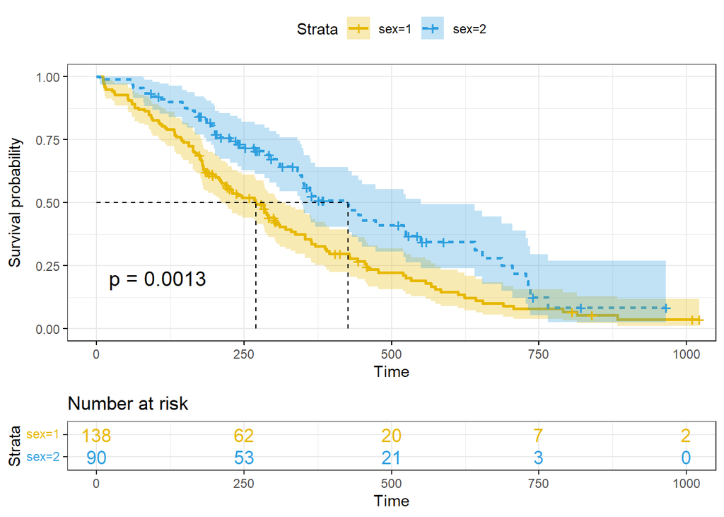

```r
## Change color, linetype by strata, risk.table color by strata
ggsurvplot(fit,
          pval = TRUE, conf.int = TRUE,
          risk.table = TRUE,               # Add risk table
          risk.table.col = "strata",       # Change risk table color by groups
          linetype = "strata",             # Change line type by groups
          surv.median.line = "hv",         # Specify median survival
          ggtheme = theme_bw(),            # Change ggplot2 theme
          palette = c("#E7B800", "#2E9FDF"))
```

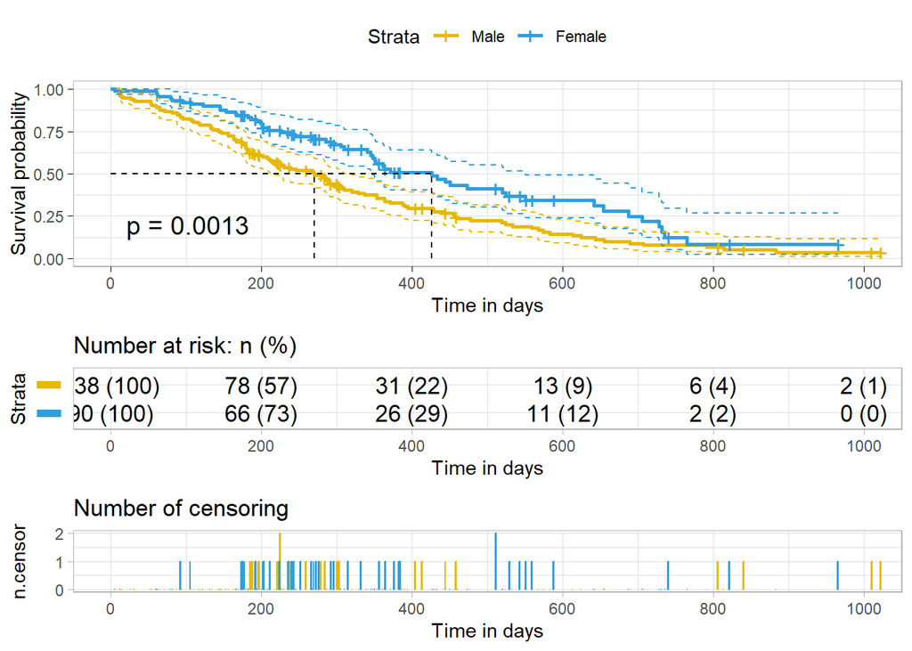

```r
## The plot can be further customized
ggsurvplot(
   fit,                     # survfit object with calculated statistics.
   pval = TRUE,             # show p-value of log-rank test.
   conf.int = TRUE,         # show confidence intervals for
                            # point estimaes of survival curves.
   conf.int.style = "step",  # customize style of confidence intervals
   xlab = "Time in days",   # customize X axis label.
   break.time.by = 200,     # break X axis in time intervals by 200.
   ggtheme = theme_light(), # customize plot and risk table with a theme.
   risk.table = "abs_pct",  # absolute number and percentage at risk.
  risk.table.y.text.col = T,# colour risk table text annotations.
  risk.table.y.text = FALSE,# show bars instead of names in text annotations
                            # in legend of risk table.
  ncensor.plot = TRUE,      # plot the number of censored subjects at time t
  surv.median.line = "hv",  # add the median survival pointer.
  legend.labs =
    c("Male", "Female"),    # change legend labels.
  palette =
    c("#E7B800", "#2E9FDF") # custom color palettes.
)
```

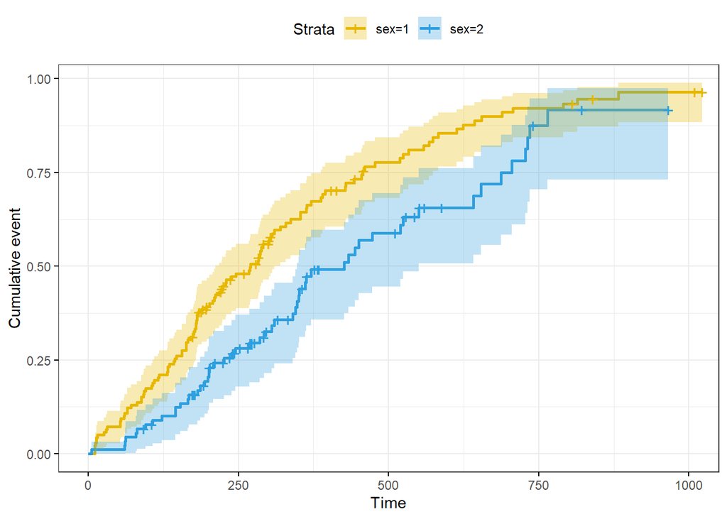

```r
### Plot cumulative events
 ## fun = "event" cumulative events
 ## fun = "log": log transformation
 ## fun = "cumhaz": cumulative hazard

## plot cumulative events
ggsurvplot(fit,
          conf.int = TRUE,
          risk.table.col = "strata",          # Change risk table color by groups
          ggtheme = theme_bw(),               # Change ggplot2 theme
          palette = c("#E7B800", "#2E9FDF"),
          fun = "event")
```

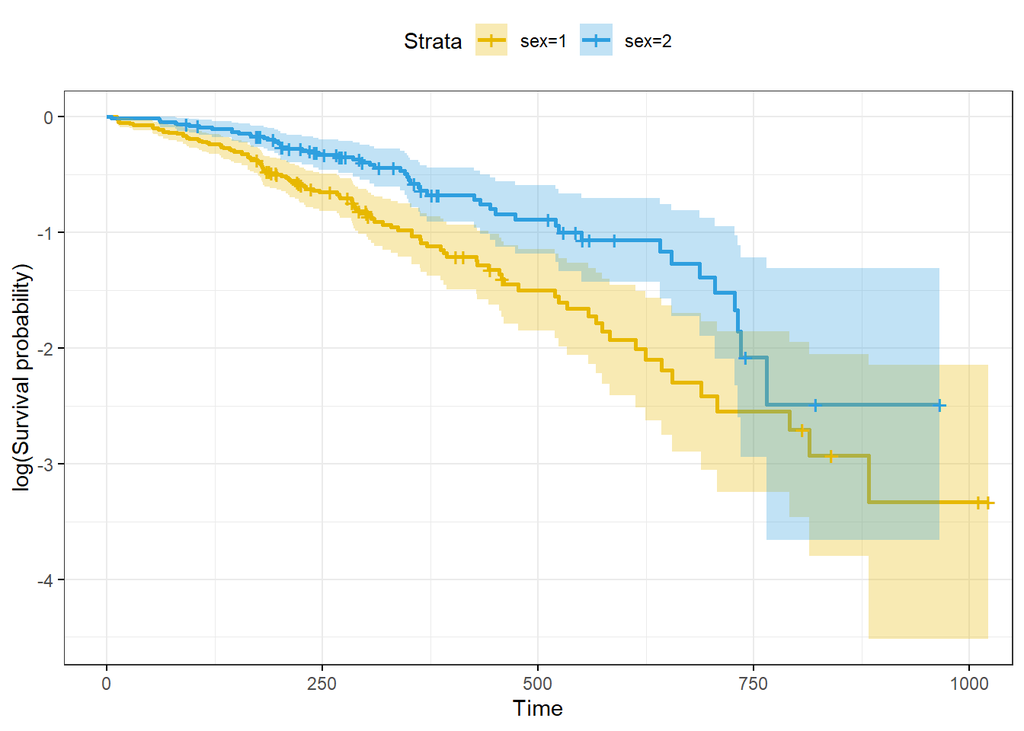

```r
## Plot log survival curve
ggsurvplot(fit,
           conf.int = TRUE,
           risk.table.col = "strata", # Change risk table color by groups
           ggtheme = theme_bw(), # Change ggplot2 theme
           palette = c("#E7B800", "#2E9FDF"),
           fun = "log")
```

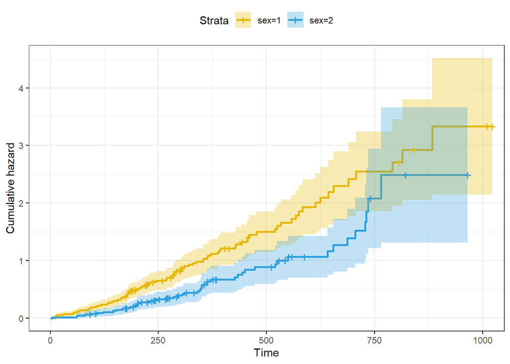

```r
## Plot cummulative hazard
## The cummulative hazard is commonly used to estimate the hazard probability
ggsurvplot(fit,
          conf.int = TRUE,
          risk.table.col = "strata", # Change risk table color by groups
          ggtheme = theme_bw(), # Change ggplot2 theme
          palette = c("#E7B800", "#2E9FDF"),
          fun = "cumhaz")
```

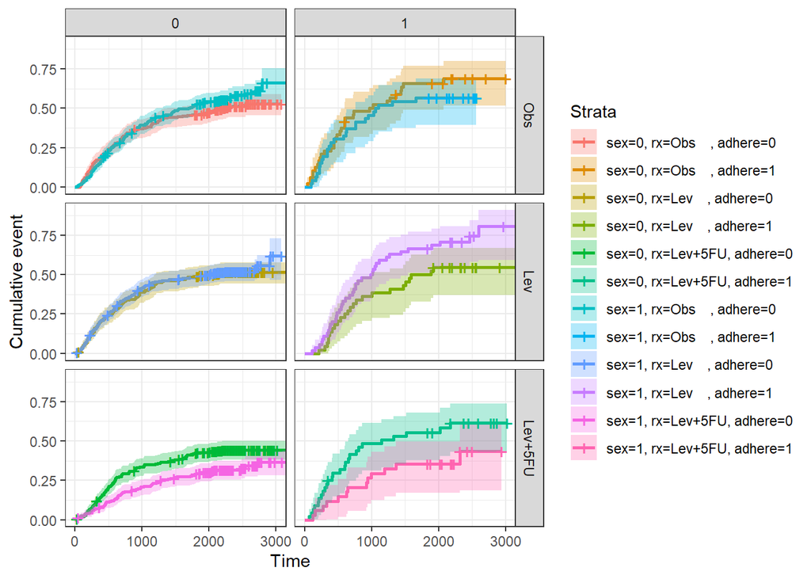

```r
## Complex survival curves in grouping
fit2 <- survfit( Surv(time, status) ~ sex + rx + adhere,
                 data = colon )
# Plot survival curves by sex and facet by rx and adhere
ggsurv <- ggsurvplot(fit2, fun = "event", conf.int = TRUE,
                     ggtheme = theme_bw())

ggsurv$plot +theme_bw() +
  theme (legend.position = "right")+
  facet_grid(rx ~ adhere)
```

## Compare the survival function

### Tests of equality of the survival function

The log-rank test, is a hypothesis test to compare the survival distributions of two samples. It is a nonparametric test and appropriate to use when the data are right-skewed and censored (technically, the censoring must be non-informative).

The logrank test is based on the same assumptions as the Kaplan-Meier survival curve—namely, that censoring is unrelated to prognosis, the survival probabilities are the same for subjects recruited early and late in the study, and the events happened at the times specified. Deviations from these assumptions matter most if they are satisfied differently in the groups being compared, for example if censoring is more likely in one group than another

The calculation of the statistic for the nonparametric “Log-Rank” and “Wilcoxon” tests is given by :

$$Q = \frac{\bigg[\sum\limits_{i=1}^m w_j(d_{ij}-\hat e_{ij})\bigg]^2}{\sum\limits_{i=1}^m w_j^2\hat v_{ij}},$$

- $d_{i j}$ is the observed number of failures in stratum $i$ at time $t_{i j}$
- $\hat{e}_{i j}$ is the expected number of failures in stratum $i$ at time $t_{i j}$
- $\hat{v}_{i j}$ is the estimator of the variance of $d_{i j}$
- $w_{j}$ is the weight of the difference at time $t_{j}$
- The log-rank or Mantel-Haenzel test uses $w_{j}=1$
- The Wilcoxon test uses $w_{j}=n_{j}$, so that differences are weighted by the number at risk at time $t_{j}$

**Specified, for group 1, the log-rank statistic can be written as**

$$\sum_{j=1}^{r}\left(d_{1 j}-e_{1 j}\right)$$
where the summation is over all unique event times (in both groups), and there are a total of $r$ such times. $d_{1 j}$ is the number of deaths that occur in group 1 at time $j$, and $e_{1 j}$ is the expected number of events in group 1 at time $j$. The expected number is given by $n_{1 j} d_{j} / n_{j}$, where $n_{j}$ is the total number of cases that are at risk just prior to time $j, n_{1 j}$ is the number at risk just prior to time $j$ in group 1, and $d_{j}$ is the total number of deaths at time $j$ in both groups.

**The Wilcoxon statistic, given by**

$$\sum_{j=1}^{r} n_{j}\left(d_{1 j}-e_{1 j}\right)$$

**strata statement in proc lifetest in SAS**

```
proc lifetest data=whas500 atrisk plots=survival(atrisk cb) outs=outwhas500;
strata gender;
time lenfol*fstat(0);
run;
```

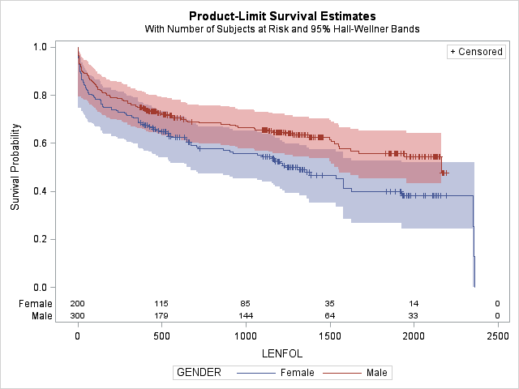

Figure: Strata statement in proc lifetest

| Test of Equality over Strata | Title | Title | Title |
| --- | --- | --- | --- |
| Test | Chi-Square | DF | Pr > Chi-Square |
| Log-Rank | 7.7911 | 1 | 0.0053 |
| Wilcoxon | 5.5370 | 1 | 0.0186 |
| -2Log(LR) | 10.5120 | 1 | 0.0012 |

**log-rank test v.s. Wilcoxon test**

- If the log-rank test is meaningful but the Wilcoxon test is meaningless, it indicates that the long-term difference may be large, but not necessarily in the early stage, and the difference may not be large.
- If the log-rank test is meaningless and the Wilcoxon test is meaningful, it indicates that there is a large difference in early survival and little difference in long-term survival. Because the Wilcoxon test is more important for early weights than for late weights (nj does not increase with time), it is not as sensitive as log-rank test to differences between groups that occur at later time points. In other words, although the two statistics test the same null hypothesis, they have different sensitivities to various deviations from the hypothesis.

> 如果对数秩检验有意义，而Wilcoxon检验毫无意义，则表明长期差异可能很大，但不一定在早期，差异可能不会很大。 如果对数秩检验无意义，而Wilcoxon检验有意义，则表明早期生存率差异很大，长期生存率差异很小。 因为Wilcoxon检验对于较早的重量比对较重的重量更重要（nj不会随时间增加）

In particular, the log-rank test is more powerful for detecting differences of the form
$$S_{1}(t)=\left[S_{2}(t)\right]^{\gamma}, \gamma > 1$$

This equation defines a proportional hazards model, the log-rank test is closely related to tests for differences between two groups that are performed within the framework of Cox’s proportional hazards model

In contrast, the Wilcoxon test is more powerful than the log-rank test in situations where event times have log-normal distributions (discussed in the next chapter) with a common variance but with different means in the two groups.

### Other nonparametric tests for STRATA statement

In addition to the log-rank and Wilcoxon tests, which are produced by default, the STRATA statement also has options for four other nonparametric tests:

- Tarone-Ware,
- Peto-Peto,
- modified Peto-Peto,
- Fleming-Harrington.

Like the Wilcoxon and log-rank tests, all of these can be represented as a weighted sum of observed and expected numbers of events:

```
STRATA treat / TESTS=ALL;
```

For the Tarone-Ware test, $w j$ is the square root of $n i$, so this test behaves much like the Wilcoxon test in being more sensitive to differences at earlier rather than later times.
$$\sum_{j=1}^{r} w_{j}\left(d_{1 j}-e_{1 j}\right)$$
That’s also true of the two Peto tests, for which $w_{j}$ is a function of the survivor function itself.
$$\sum_{j=1}^{r} \hat{S}\left(t_{j}\right)\left(d_{1 j}-e_{1 j}\right)$$
Fleming-Harrington is actually a family of tests in which the weights depend on two parameters, $p$ and $q$ which can be chosen by the user:
$$w_{j}=\hat{S}\left(t_{j}\right)^{p}\left[1-\hat{S}\left(t_{j}\right)\right]^{q}$$

- When both $\mathrm{p}$ and $\mathrm{q}$ are 0 , you get the log-rank test.
- When $\mathrm{p}$ is 1 and $\mathrm{q}$ is 0 , you get something very close to the Peto-Peto test.
- When $\mathrm{q}$ is 1 and $\mathrm{p}$ is 0 , wi increases with time, unlike any of the other tests.

### Multiple comparisons

When more than one strata, the ADJUST option tells PROC LIFETEST to produce p-values for all six pairwise comparisons of the four strata and then to report p-values that have been adjusted for multiple comparisons using Tukey’s method (other methods are also available):

```
PROC LIFETEST DAta=my.recid;
 TIME week*arrest(0);
 STRATA wexp paro / ADJUST=TUKEY;
RUN;
```

For numeric variables, you can use the STRATA statement to define groups by intervals rather than by unique values.

```
PROC LIFETEST DAta=my.recid;
 TIME week*arrest(0);
 STRATA age(21 24 28) / ADJUST=BON;
RUN;

     age < 21
21 ≤ age < 24
24 ≤ age < 28
28 ≤ age
```

### Comparing survival functions using Log-Rank HR

One way to compare two survival curves is to calculate the hazard ratio (HR)

```
proc lifetest data=whas500 atrisk plots=hazard(bw=200) outs=outwhas500;
    strata bmi(15,18.5,25,30,40);
    time lenfol*fstat(0);
run;
```

作为Kaplan-Meier计算的一部分，计算每个组中观察到的事件 (通常为死亡) 的数量, 以及假设生存时间 没有差异的零假设的预期事件的数量。危险比为: - Treatment A and Treatment B. the observed and expected deaths are summed, to give - $O_{A}=\Sigma O_{A t}, O_{B}=\Sigma O_{B t}, E_{A}=\Sigma E_{A t}$, and $E_{B}=\Sigma E_{B t}$ - Finally the Logrank statistic is calculated as
$$\chi_{\text {Logrank }}^{2}=\frac{\left(O_{A}-E_{A}\right)^{2}}{E_{A}}+\frac{\left(O_{B}-E_{B}\right)^{2}}{E_{B}}$$
- It can be written as
$$\chi_{\text {Logrank }}^{2}=\left(O_{A}-E_{A}\right)^{2}\left(\frac{1}{E_{A}}+\frac{1}{E_{B}}\right)$$
- since $\left(O_{A}-E_{A}\right)^{2}=\left(O_{B}-E_{B}\right)^{2}$. - We can obtain the ratio $O_{A} / E_{A}$ and $\left.O_{B} / E_{B}\right)$, we can calculate the hazard ratio HR, defined as the ratio of these two relative death rates; that is,
$$H R=\frac{O_{A} / E_{A}}{O_{B} / E_{B}}$$

**Confidence Interval of HR**

In calculating $C I s$, it is convenient if the statistic under consideration can be assumed to follow an approximately Normal distribution. However, the estimate of the $H R$ is not normally distributed. In particular it has a possible range of values from 0 to $\infty$, with the null hypothesis value of unity not located at the centre of this interval. To make the scale symmetric and to enable us to calculate $C I s$, we transform the estimate to make it approximately normally distributed. We do this by using log $H R$, rather than $H R$ itself, as the basis for our calculation. It is possible to show that a general $100(1-\alpha) \% C I$ for the $\log H R$ is Convert the estimated value to an approximately normal distribution. For this, we use logarithmic HR
$$\log H R-\left[z_{1-\alpha / 2} \times S E(\log H R)\right] \text { to } \log H R+\left[z_{1-\alpha / 2} \times S E(\log H R)\right]$$
HR itself is then
$$\exp \left[\operatorname { l o g } H R - [ z _ { 1 - \alpha / 2 } \times S E ( \operatorname { l o g } H R ) ] \text { to } \operatorname { e x p } \left[\log H R+\left[z_{1-\alpha / 2} \times S E(\log H R)\right]\right.\right.$$
In both these expressions
$$S E(\log H R)=\sqrt{\left(\frac{1}{E_{A}}+\frac{1}{E_{B}}\right)}$$

### Mantel-Haenszel HR

在研究中的事件总数很小的情况下, $S E(\log H R)$ 的估计并不总是可靠的。但对 $S E$ 的首选估计值需要 在每个死亡时间计算方差，称为超几何方差 hypergeometric variance 。始终总结这些差异会导致Logrank 测试的Mantel-Haenszel版本。时间 $t$ 的超几何方差由下式给出:
$$V_{t}=\frac{m_{t} n_{t} r_{t} s_{t}}{N_{t}^{2}\left(N_{t}-1\right)}$$
If all deaths occur at different times, that is, there is no fixed observation value, then
$$r{t}=1, s{t}=N_{t}-1$$
$$V_{t}=m_{t} n_{t} / N_{t}^{2} .$$
As for both $E_{A t}$ and $E_{B t}$, we finally sum the individual $V_{t}$ calculated at each distinct event time to obtain $V=\Sigma V_{t}$. The Mantel-Haenszel test statistic is then defined as
$$\chi_{M H}^{2}=\frac{\left(O_{A}-E_{A}\right)^{2}}{V}$$
This has an approximate $\chi^{2}$ distribution with $d f=1$ in the same way as the Logrank test. It should be noted that $\chi_{M H}^{2}$ only differs from $\chi_{\text {Logrank }}^{2}$ by the expression for $V$. The use of the Mantel-Haenszel statistic to test for the difference between two groups also gives an alternative estimate of the HR:
$$H R_{M H}=\exp \left(\frac{O_{A}-E_{A}}{V}\right)$$
The corresponding $S E$ of the Mantel-Haenszel $\log H R_{M H}$ is
$$S E\left(\log H R_{M H}\right)=1 / V^{1 / 2}$$
This $S E\left(\log H R_{M H}\right)$ can be used to give $C I$ s derived from the Mantel-Haenszel estimate of the $H R$ as
$$\exp \left[\log H R_{M H}-\left(z_{1-\alpha / 2} / V^{1 / 2}\right)\right] \text { to } \exp \left[\log H R_{M H}+\left(z_{1-\alpha / 2} / V^{1 / 2}\right)\right]$$

See more under **Survival Analysis-Survival Analysis Using SAS - A Practical Guide (2nd Edition)**

### Analysis-of-covariance (Adjustment)

**References**: Heller G. and Venkatraman E.S. (2004) A nonparametric test to compare survival distributions with covariate adjustment. JRSS-B 66, 719-733.

The analysis of covariance is a technique that is used to improve the power of a k-sample test by adjusting for concomitant variables. In the classic normal linear model, this technique is used for increasing the precision of the k-sample test statistic derived from a randomized study or to adjust for sources of bias in observational studies. The power of the adjusted test statistic is a function of the strength of the association between the covariates and the response. However, the increase in power comes at the cost of model specification. The assumption of a specific linear regression function and a normal error distribution is imposed on the model structure. If either of these assumptions is incorrect, the resulting inference that is drawn from the adjusted test is questionable.

> 协方差分析是一种通过调整伴随变量来提高 k 样本检验功效的技术。在经典的正态线性模型中，此技术用于提高从随机研究得出的 k 样本检验统计量的精度，或调整观察性研究中的偏倚来源。调整后的检验统计量的功效是协变量与响应之间关联强度的函数。然而，功率的增加是以模型规格为代价的。对模型结构强加了特定线性回归函数和正态误差分布的假设。如果这些假设中的任何一个不正确，则从调整后的测试中得出的推论是有问题的。

For the proportional hazards model, the primary assumptions are that the relative risk function $\lambda(t \mid z, \mathbf{x}) / \lambda_{0}(t)$ is

1. time invariant and
2. represented by a log-linear function of the covariates.

For the analysis-of-covariance survival problem, an incorrect model specification can lead to erroneous inference on the group effect.

In this paper, a k-sample test statistic is developed for survival time data with the right censoring present which adjusts for three or fewer concomitant covariates but does not require the assumption of proportional hazards or a parametric specification of the relative risk function. The statistic is asymptotically valid when the observed covariates and the group classifier are either independent or dependent, assuming that the underlying failure time and censoring variables are independent conditionally on the group classification and covariates.

> 对于协方差生存问题的分析，不正确的模型规范会导致对组效应的错误推断。

> 在本文中，为生存时间数据开发了一个 k 样本检验统计量，其中存在正确的删失，它针对三个或更少的伴随协变量进行调整，但不需要假设比例风险或相对风险函数的参数规范。当观察到的协变量和组分类器独立或相关时，统计量渐近有效，假设基础失效时间和审查变量在组分类和协变量的条件下独立。

```r
library(clinfun)
library(survival)
data(pbc)
pbc1 <- pbc
pbc1$trt[pbc1$trt == -9] <- NA
pbc1$copper[pbc1$copper == -9] <- NA
calogrank(pbc1$time, pbc1$status, pbc1$trt, pbc1[,c("copper")])
```

```
## Call:
## calogrank(ftime = pbc1$time, fstatus = pbc1$status, grp = pbc1$trt,
##     cvt = pbc1[, c("copper")])
##
## n=143, 167 Beobachtungen als fehlend gelöscht.
##
##        N Observed Expected Exptd-adj (O-E)^2/V (O-aE)^2/aV
## grp=1 74       64     64.8      9.91     0.023        28.0
## grp=2 69       60     59.2      9.09     0.023        24.8
##
##  Unconditional chisq= 0.02  on 1 degrees of freedom, p= 0.88
##       Adjusted chisq= 0.15  on 1 degrees of freedom, p= 0.697
```

```r
calogrank(pbc1$time, pbc1$status, pbc1$trt, pbc1[,c("protime", "copper")])
```

```
## Call:
## calogrank(ftime = pbc1$time, fstatus = pbc1$status, grp = pbc1$trt,
##     cvt = pbc1[, c("protime", "copper")])
##
## n=143, 167 Beobachtungen als fehlend gelöscht.
##
##        N Observed Expected Exptd-adj (O-E)^2/V (O-aE)^2/aV
## grp=1 74       64     64.8      9.93     0.023        46.3
## grp=2 69       60     59.2      9.07     0.023        41.1
##
##  Unconditional chisq= 0.02  on 1 degrees of freedom, p= 0.88
##       Adjusted chisq= 0.56  on 1 degrees of freedom, p= 0.453
```

## Accelerated failure time (AFT) model

### Introduction

The accelerated failure time model (AFT model) is a parametric model that can replace the commonly used proportional hazard model. The proportional hazard model assumes that the role of the covariate is to multiply the risk by a certain constant, while the AFT model assumes that the role of the covariate is to **accelerate or slow down the life course of the disease by a certain constant.** The AFT model describes the relationship between the survivor functions of any two individuals in its most general form.

Assuming that $T$ is the failure time and $x$ is the covariate, the assumption of the accelerated failure time model is that the survival time of a person is equal to the baseline survival time of the population, the acceleration factor of this person, and its mathematical form is as follows:
$$T=t * e^{\theta \cdot x}, t=e^{\mu+\sigma * W}$$
Common forms also include:
$$S(t \mid x)=S_{0}\left(t * e^{\theta \cdot x}\right)$$
$$Y=\log (T)=\mu+\gamma \cdot x+\sigma * W$$
Among them, the baseline survival time $t$ of the population obeys a certain probability distribution, and the $W$ is also a random variable that obeys a certain probability distribution.

**PH & AFT**

- AFT Model is based on time T modeling, and PH Model is based on Hazard modeling
- Weibull regression is the only regression that satisfies both model assumptions

For PH Model:
$$\quad \lambda_{i}(t)=\lambda_{0}(t) \exp \left(x_{i}^{T} \beta\right)$$
For AFT Model:
$$\lambda_{i}(t)=\lambda_{0}\left(\exp \left(-x_{i}^{T} \beta\right) t\right) \exp \left(-x_{i}^{T} \beta\right)$$

这是由于 $T_{i}=\exp \left(x_{i}^{T} \beta\right) T_{0}$, 因此
$$S_{i}(t)=P\left(T_{i} \geq t\right)=P\left(T_{0} \geq \exp \left(-x_{i}^{T} \beta\right) t\right)=S_{0}\left(\exp \left(-x_{i}^{T} \beta\right) t\right)$$
$$f_{i}(t)=f_{0}\left(\exp \left(-x_{i}^{T} \beta\right) t\right) \exp \left(-x_{i}^{T} \beta\right)$$
$$\lambda_{i}(t)=\exp \left(-x_{i}^{T} \beta\right) \lambda_{0}\left(\exp \left(-x_{i}^{T} \beta\right) t\right)$$

PH Model:
$$\log \lambda_{i}(t)=\log \lambda_{0}(\exp (\log t))+x_{i}^{T} \beta$$
AFT Model:
$$\log \lambda_{i}(t)=\log \lambda_{0}\left(\exp \left(\log t-x_{i}^{T} \beta\right)\right)-x_{i}^{T} \beta$$

### PROC LIFEREG

The LIFEREG program uses the maximum likelihood method to generate the estimated value of the parameter regression model using censored survival data [method of maximum likelihood]. To some extent, PROREG LIFEREG has been obscured by the PHREG program, which uses a method known as partial likelihoo for semiparametric regression analysis [method known as partial likelihoo].

PROC LIFEREG is by no means obsolete. It can do some better things than PROC PHREG, and it can do other things that PROC PHREG simply cannot do:

- PROC LIFEREG accommodates left censoring and interval censoring. PROC PHREG allows only right censoring.
- With PROC LIFEREG, you can test certain hypotheses about the shape of the hazard function. PROC PHREG gives you only nonparametric estimates of the survivor function, which can be difficult to interpret.
- If the shape of the survival distribution is known, PROC LIFEREG produces more efficient estimates (with smaller standard errors) than PROC PHREG.
- PROC LIFEREG can easily generate predicted event times for any specified set of covariate values. This is more difficult with PHREG, and often impossible.
- PROC LIFEREG’s greatest limitation is that it does not handle time-dependent covariates, something at which PROC PHREG excels.

What PROC LIFEREG actually estimates is a special case of this model that is quite similar in form to an ordinary linear regression model. Let $T_{i}$ be a random variable denoting the event time for the ith individual in the sample, and let $x_{i 1}, \ldots, x_{i k}$ be the values of $k$ covariates for that same individual. The model is then
$$\log T_{i}=\beta_{0}+\beta_{1} x_{i 1}+\ldots+\beta_{k} x_{i k}+\sigma \varepsilon_{i}$$
where $\varepsilon_{i}$ is a random disturbance term, and $\beta_{0}, \ldots, \beta_{k}$, and $\sigma$ are parameters to be estimated. Exponentiating both sides gives an alternative way of expressing the model:
$$T_{i}=\exp \left(\beta_{0}+\beta_{1} x_{i 1}+\ldots+\beta_{k} x_{i k}+\sigma \varepsilon_{i}\right)$$
In regression analysis, $-\log (T)$ represents fixed effects, and $\epsilon$ represents noise. Different $\epsilon$ distribution means different distribution of $T_{0}$.

According to a simple transformation, we have $T_{i}=\exp \left(x_{i}^{T} \beta\right) T_{0}, T_{0}=\exp (W)$. Therefore, the AFT model parameter $\beta$ represents: when the jth dimension changes in $\Delta_{j}$, the survival time will change $\exp \left(\Delta_{j} \beta_{j}\right )$

### Residuum distribution

Assuming $Y=\log T$, the AFT Model can be expressed as
$$Y_{i}=x_{i}^{T} \beta+W_{i}$$
$W_{i} \sim f$ represents the **independent residual**

- If $W \sim N\left(0, \sigma^{2}\right)$, the model at this time is called **Lognormal-AFT Model**. Because the assumption of normality for $Y$ is equivalent to the assumption of lognormality. At this time, if there is no censorship, we can directly use the LSE (least squares) method to solve the problem (in fact, there is rarely such a possibility). Survival data usually has at least some vetted observations, and it is difficult to process these observations with **OLS (Ordinary Least Squares)**. Instead, we can use **maximum likelihood estimation**.
- If $W \sim W \operatorname{libull}(\lambda, \gamma)$, the model at this time is called **Weibull regression model**. It is a special AFT Model.
- Following surmmaries the model

$$\begin{array}{c|l}
\text { Distribution of } \varepsilon & \text { Distribution of } T \\
\hline \text { extreme value (2 par.) } & \text { Weibull } \\
\text { extreme value (1 par.) } & \text { exponential } \\
\text { log-gamma } & \text { gamma } \\
\text { logistic } & \text { log-logistic } \\
\text { normal } & \text { log-normal }
\end{array}$$

**Specify Model in SAS**

```
*** Lognormal-AFT Model;
PROC LIFEREG DATA=recid;
 MODEL week*arrest(0)=fin age race wexp mar paro prio / DISTRIBUTION=LNORMAL;
RUN;
```

### Exponential Model

The simplest model estimated by PROC LIFEREG is the exponential model, which is called by DISTRIBUTION = EXPONENTIAL in the MODEL statement. The model specifies that $\varepsilon$ has a standard extreme-value distribution and constrains $\sigma=1$. If $\varepsilon$ has an extreme value distribution, then the logarithm T also has an extreme value distribution, provided that the covariate is the condition. Constant hazard function, expresses the exponential regression model as
$$\log h(t)=\beta_{0}^{\bullet}+\beta_{1}^{\bullet} x_{1}+\ldots+\beta_{k}^{\bullet} x_{k}$$

**Interpretation**

$$\lambda_{i}(t)=\lambda(t) \exp \left(x_{i}^{T} \beta\right), \lambda(t) \geq 0$$
Where $\lambda(t)=\lambda$
$$\frac{\lambda_{1}(t)}{\lambda_{2}(t)}=\exp \left(\Delta_{j} \beta_{j}\right), \Delta_{j}=x_{1 j}-x_{2 j}$$
Therefore, the meaning of the parameter $\beta_{j}$ is: when the data $x_{j}$ changes with the size of $\Delta_{j}$, the Hazard Ratio of the model will change $\exp \left(\Delta_{ j} \beta_{j}\right)$

### Weibull Model

The Weibull model is a slight modification of the exponential model with great consequences. By specifying DISTRIBUTION = WEIBULL in the MODEL statement, we retain the assumption that $\varepsilon$ has a standard extreme value distribution, but **relax the assumption of $\sigma=1$.**

- When $\sigma$> 1, the danger decreases with time.
- When $0.5<\sigma<1$, the risk is increasing at a reduced rate.
- When $0<\sigma<0.5$, the danger is increasing at an increasing rate.
- -When $\sigma=0.5$, the hazard function is a straight line and its starting point is 0.

**Weibull Distribution**

$$\begin{array}{l}
\lambda(t)=\lambda \gamma(t \lambda)^{\gamma-1} \\
\Lambda(t)=(t \lambda)^{\gamma} \\
S(t)=\exp \left[-(t \lambda)^{\gamma}\right] \\
f(t)=\lambda \gamma(t \lambda)^{\gamma-1} \exp \left((t \lambda)^{\gamma}\right)
\end{array}$$

**Connection with exponential distribution**

If $X \sim \operatorname{Exp}(\tau)$, then $T=X^{\sigma} \sim$ Weibull $\left(\gamma=1 / \sigma, \lambda=\tau^{\ sigma}\right)$ also, - For exponential distribution, $\quad \log S(t)=(-\log t)+C_(1)$ - For Weibull distribution, $\quad \log S(t)=\gamma(-\log t)+C_{2}$

T has a Weibull distribution conditioned on covariates.it has a relatively simple survival function, which is easy to manipulate mathematically: (where $\mathbf{x}_{i}$ is a vector of the covariate values and $ $ is a vector of coefficients.)
$$S_{i}(t)=\exp \left\{-\left[t_{i} e^{-\beta \mathbf{x}_{i}}\right]^{\frac{1}{\sigma}}\right\}$$
Secondly, in addition to the AFT model, the Weibull model is also a proportional hazard model. This means that its coefficient (after proper conversion) can be interpreted as a relative hazard ratio. In fact, the Weibull model (and its special case, the exponential model) is the only model that belongs to both categories. Like the exponential model, there is a completely equivalent relationship between the logarithmic risk forms of the model
$$\log h(t)=\alpha \log t+\beta_{0}^{\bullet}+\beta_{1}^{\bullet} x_{1}+\ldots+\beta_{k}^{\bullet} x_{k}$$
and the log-survival time model
$$\log T_{i}=\beta_{0}+\beta_{1} x_{1}+\ldots+\beta_{k} x_{k}+\sigma \varepsilon$$
However, the relationship between the parameters is slightly more complicated. Specifically, for the Weibull model
$$\beta_{j}^{\bullet}=\frac{-\beta_{j}}{\sigma} \text { for } j=1, \ldots, k$$
$$\alpha=(1 / \sigma)-1.$$

[output not shown]

### Log-Normal Model

Unlike the Weibull model, the lognormal model has a non-monotonic hazard function. When t=0, the danger is 0. It rises to a peak, and then drops to 0 as t approaches infinity. The log normal is not a proportional hazard model, and its risk function cannot be expressed in a closed form. However, it can be expressed as a regression model, where the dependent variable is the log hazard.
$$\log h(t)=\log h_{0}\left(t e^{-\beta x}\right)-\beta \mathbf{x}$$
where $h_{0}$ (.) can be interpreted as the hazard function for an individual with $\mathbf{x}=\mathbf{0}$. (personal hazard function)

### Log-Logistic Model

An inverted U-shaped hazard is the log-logistic model, which assumes that ε has a logistic distribution with
$$f(\varepsilon)=\frac{e^{\varepsilon}}{\left(1+e^{\varepsilon}\right)^{2}}$$

DISTRIBUTION=LLOGISTIC, The logical distribution is symmetrical, with an average value of 0, and is very similar in shape to the normal distribution. If $\varepsilon$ has a logarithmic distribution, then the logarithm $T$ (although the mean is non-zero) has a logarithmic distribution. The loglogistic hazard function is
$$h(t)=\frac{\lambda \gamma(\lambda t)^{\gamma-1}}{1+(\lambda t)^{\gamma}}$$
where $\gamma=1 / \sigma$, and
$$\lambda=\exp \left\{-\left[\beta_{0}+\beta_{1} x_{1}+\ldots+\beta_{k} x_{k}\right]\right\}$$

- When $\sigma<1$, the logarithmic logic hazard is similar to the lognormal hazard: starting from 0, rising to the peak, and then falling to 0.
- When $\sigma>1$, the hazard behaves like a diminishing Weibull hazard: it starts at infinity and then decreases towards 0.
- When $\sigma=1$, the hazard value at t $=0$ is $\lambda$, and then decreases toward 0 as t tends to infinity.

Although the logarithmic logic model has the complexity of the hazard function, it has a fairly simple survival function
$$S(t)=\frac{1}{1+(\lambda t)^{\gamma}}$$
As before, $\gamma=1 / \sigma$ and $\lambda=\exp \left\{-\left[\beta_{0}+\beta_{1} x_{1}+\ldots+\beta_{k} x_{k}\right]\right\} .$ A little algebra shows that this can be written as
$$\log \left[\frac{S(t)}{1-S(t)}\right]=\beta_{0}^{\bullet}+\beta_{1}^{\bullet} x_{1}+\ldots+\beta_{k}^{\bullet} x_{k}-\gamma \log t$$
Where $\beta_{i}^{\bullet}=\beta_{i} / \sigma$ for $i=1, \ldots, k$. 这只是事件 $t$ 之前发生的概率的逻辑回归模型。

### Fit statistics for model comparsion

**The statistical information largely depends on the sample size.**

- Akaike’s information criterion (AIC), is a modification of the $-2$ log-likelihood that penalizes models for having more covariates. where $\mathrm{k}$ is the number of covariates.
  $$A I C=-2 \log L+2 k$$
- (AICC) is a “corrected” version of the AIC that may have better behavior in small samples:
  $$A I C C=A I C+\frac{2 k(k+1)}{n-k-1}$$
- Bayesian information criterion (also known as Schwarz’s criterion) gives a more severe penalization for additional covariates (对其他协变量进行更严厉的惩罚)
  $$B I C=-2 \log L+k \log n$$

### Graphical method for distinguishing different distributions in SAS

- the PLOTS=LS option produces a plot of -log and t. If the true distribution is an exponential distribution, the graph should produce a straight line with an origin of 0
- The LLS option produces a plot of −loglog versus log t, if the true distribution is Weibull, it should be a straight line;

### Prediction and hazard function

After fitting the model with PROC LIFEREG, sometimes it is desirable to generate predicted survival times for the observations in the data set. If a single point estimate is to be made for each person, the predicted median survival time may be the best. You can easily get this information using the OUTPUT statement.

P in the OUTPUT statement = option request percentile. By default, PROC LIFEREG calculates the 50th percentile (ie median). You can use the QUANTILE keyword to request other percentiles, as described in the PROC LIFEREG documentation. The STD keyword requests the standard error of the median.

```
PROC LIFEREG DATA=recid;
 MODEL week*arrest(0)=fin age race wexp mar paro prio
 / D=WEIBULL;
 OUTPUT OUT=a P=median STD=s;
RUN;
```

**Predict the probability of survival to a specified time**

```
PROC LIFEREG DATA=recid OUTEST=a;
 MODEL week*arrest(0) = fin age race wexp mar paro prio
 / D=WEIBULL;
 OUTPUT OUT=b XBETA=lp;
RUN;
%PREDICT(OUTEST=a,OUT=b,XBETA=lp,TIME=30)


%macro predict (outest=, out=_last_,xbeta=,time=);
 data _pred_;
 _p_=1;
 set &outest point=_p_;
 set &out;
 lp=&xbeta;
 t=&time;
 gamma=1/_scale_;
 alpha=exp(-lp*gamma);
 prob=0;
 _dist_=upcase(_dist_);
 if _dist_='WEIBULL' or _dist_='EXPONENTIAL' or _dist_='EXPONENT' then prob=exp(-
 alpha*t**gamma);
 if _dist_='LOGNORMAL' or _dist_='LNORMAL' then prob=1-probnorm((log(t)-lp)/_scale_);
 if _dist_='LLOGISTIC' or _dist_='LLOGISTC' then prob=1/(1+alpha*t**gamma);
 if _dist_='GAMMA' then do;
  d=_shape1_;
  k=1/(d*d);
  u=(t*exp(-lp))**gamma;
  prob=1-probgam(k*u**d,k);
  if d lt 0 then prob=1-prob;
  end;
 drop lp gamma alpha _dist_ _scale_ intercept
  _shape1_ _model_ _name_ _type_ _status_ _prob_ _lnlike_ d k u;
 run;
 proc print data=_pred_;
 run;
%mend predict;

*** %LIFEHAZ generated a graph of hazard versus time;
PROC LIFEREG DATA=recid OUTEST=a;
 MODEL week*arrest(0) = fin age race wexp mar paro prio
 / D=WEIBULL;
 OUTPUT OUT=b XBETA=lp;
RUN;
%LIFEHAZ(OUTEST=a,OUT=b,XBETA=lp)

%macro lifehaz(outest=,out=,obsno=0,xbeta=lp);
data;
 set &outest;
 call symput('time',_NAME_);
run;
proc means data=&out noprint;
 var &time &xbeta;
 output out=_c_ min(&time)=min max(&time)=max mean(&xbeta)=mean;
run;
data;
 set &outest;
 call symput('model',_dist_);
 s=_scale_;
 d=_shape1_;
 _y_=&obsno;
 set _c_ (keep=min max mean);
 if _y_=0 then m=mean;
 else do;
 set &out (keep=&xbeta) point=_y_;
 m=&xbeta;
 end;
 inc=(max-min)/300;
 g=1/s;
 alph=exp(-m*g);
 _dist_=upcase(_dist_);
if _dist_='LOGNORMAL' or _dist_='LNORMAL' then do;
 do t=min to max by inc;
 z=(log(t)-m)/s;
 f=exp(-z*z/2)/(t*s*sqrt(2*3.14159));
 Surv=1-probnorm(z);
 h=f/Surv;
 output;
 end;
end;
else if _dist_='GAMMA' then do;
 k=1/(d*d);
 do t=min to max by inc;
 u=(t*exp(-m))**(1/s);
 f=abs(d)*(k*u**d)**k*exp(-k*u**d)/(s*gamma(k)*t);
 Surv=1-probgam(k*u**d,k);
 if d lt 0 then Surv=1-Surv;
 h=f/Surv;
 output;
 end;
end;
else if _dist_='WEIBULL' or _dist_='EXPONENTIAL' or _dist_='EXPONENT' then do;
 do t=min to max by inc;
 h=g*alph*t**(g-1);
 output;
 end;
end;
else if _dist_='LLOGISTIC' or _dist_='LLOGISTC' then do;
 do t=min to max by inc;
 h=g*alph*t**(g-1)/(1+alph*t**g);
 output;
 end;
end;
else put 'ERROR:DISTRIBUTION NOT FITTED BY LIFEREG';
run;
proc gplot;
 plot h*t / haxis=axis2 vaxis=axis1 vzero;
 symbol1 i=join v=none c=black;
 axis1 label=(f=titalic angle=90 'Hazard');
 axis2 label=(f=titalic justify=c 'time' f=titalic justify=c "&model");
run; quit;
%mend lifehaz;
```

### Left Censoring and Interval Censoring

PROC LIFEREG excludes any observations with a time of 0 or less, because it must take the logarithm of the event time as the first step. One way is to assign some arbitrarily chosen number between 0 and 1. A more elegant solution is to treat this situation as being censored at time 1.

- For uncensored observations, LOWER and UPPER have the same value.
- For observations with YEARS=0, we set LOWER=. and UPPER=1.
- For right-censored observations (including those with events other than the one of interest), UPPER=. and LOWER=YEARS.
- If both UPPER and LOWER are missing (which happens for individuals with YEARS=0 who have events other than the one of interest), the observation is excluded. T

```
DATA leaders2;
 SET leaders;
 lower=years;
 upper=years;
 IF years=0 THEN DO;
 lower=.;
 upper=1;
 END;
 IF lost IN (0,1,2) THEN upper=.;
RUN;

*** fit an exponential model;
PROC LIFEREG DATA=leaders2;
 CLASS region;
 MODEL (lower,upper)= manner start military age conflict
 loginc literacy region / D=EXPONENTIAL;
RUN;
```

## Cox Proportional Hazards Model

### Introduction

The basic model that does not include time-dependent covariates or nonproportional hazards. The model is usually written as
$$h_{i}(t)=\lambda_{0}(t) \exp \left(\beta_{1} x_{i 1}+\ldots+\beta_{k} x_{i k}\right)$$
Taking the logarithm of both sides, we can rewrite the model as
$$\log h_{i}(t)=\alpha(t)+\beta_{1} x_{i 1}+\ldots+\beta_{k} x_{i k}$$
Take the ratio of the hazards for two individuals $i$ and $j$
$$\frac{h_{i}(t)}{h_{j}(t)}=\exp \left\{\beta_{1}\left(x_{i 1}-x_{j}\right)+\ldots+\beta_{k}\left(x_{i k}-x_{j k}\right)\right\}$$

**Partial Likelihood**

尚若不考虑删失, $\quad j$ 个观测 $T_{1} \sim \lambda_{1}(t), T_{2} \sim \lambda_{2}(t), \ldots T_{j} \sim \lambda_{j}(t)$ 在Cox Regression的假设下满 足
$$P\left(T_{1}<T_{2}<\ldots<T_{J}\right)=\prod_{i=1}^{J} \frac{\lambda_{j}(t)}{\sum_{k=j}^{J} \lambda_{k}(t)}=\prod_{i=1}^{J} \frac{\exp \left(x_{j}^{T} \beta\right)}{\sum_{k=j}^{J} \exp \left(x_{k}^{T} \beta\right)}$$
Furthermore, when the censor be considered, the time point of death event is denoted as $t_{j}$, then the $\mathrm{P}(death)$
$$\mathrm{P}(death)=\frac{\exp \left(x_{j}^{T} \beta\right)}{\sum_{k \in R\left(t_{j}\right)} \exp \left(x_{k} \beta\right)}$$
given the subject’s covariates $\beta$; the joint probability of observing each subject’s failure time can be calculated given the subject’s covariates values $x_{j}$ likelihood $L(\beta)$ could be expressed as
$$L(\beta)=\prod_{j} \frac{\exp \left(x_{j}^{T} \beta\right)}{\sum_{k \in R\left(t_{j}\right)} \exp \left(x_{k} \beta\right)}$$
$k \in R\left(t_{j}\right)$ represents at time $t_{j}-$ the subject $k$ is still alive. Here we temporarily assume that there is only one death observation at time $t_{j}$.

Strictly speaking, this is not a likelihood function. **Because the likelihood function should represent the continuous multiplication of the distribution function under the given data**, but the above formula is obviously not. Even speaking, the continuous multiplication should be about the continuous multiplication of the individual, and the above formula is about the point in time. Cox (1975) called this form of likelihood Partial Likelihood, and proved that all its properties are the same as likelihood.

### Parameter estimate

#### NR iteration for parameter estimate

The iteration form is
$$\hat{\beta}^{(r+1)}=\hat{\beta}^{(r)}+\left(X^{T} WX\right)^{-1} X^{T} (dP d)$$

#### Model fitting in SAS

```
proc phreg data = whas500;
    class gender;
    model lenfol*fstat(0) = gender age;
run;

## Output
## “Ties Handling: BRESLOW.”
   This line refers to the default method for handling ties—two or more
   observations that have exactly the same event time. Although Breslow’s method
   is nearly universal

## Analysis of Maximum Likelihood Estimates

## Model Fit Statistics
## -2 LOG L
## AIC
## SBC: Schwartz’s Bayesian criterion (SBC) statistics
   The main purpose is to punish models with more covariates, allowing people to compare non-nested models

## Testing Global Null Hypothesis
## Displays test of hypothesis that all coefficients in the model are 0
   模型整体是否可以预测危险率变化的整体检验。这些检验是渐近的等价比, 一般首选似然比检验
## Likelihood Ratio
## Socre
## Wald
```